# Introduction to Matplotlib

2024

## Introduction to Matplotlib

- Matplotlib is a comprehensive library for creating publication quality static, animated, and interactive visualizations in Python.

## Install with conda

```
conda install matplotlib
```

## Import and use: code

```python
import matplotlib.pyplot as plt
x = [1, 2, 3]
y = [1, 4, 9]
plt.plot(x, y)
plt.show()
```

## Import and use: plot

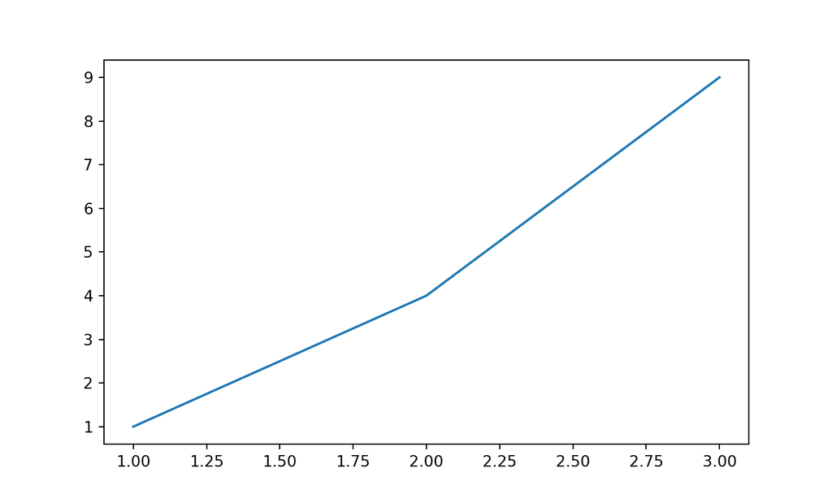

## Basic Matplotlib Terminology

- **Figure**: The whole figure which may contain one or more axes (plots). Think of the figure as the canvas.
- **Axes**: This is what you think of as a plot, a region of the figure that displays data. A figure can contain many Axes.
- **Axis**: These are the number-line-like objects. They take care of setting the graph limits and generating the ticks and ticklabels.
- **Artist**: Everything you can see on the figure is an artist (even the Figure, Axes, and Axis objects). This includes Text objects, Line2D objects, collections objects, Patch objects, etc.

## Example of plot components: code

```python
import matplotlib.pyplot as plt
import numpy as np

# Create a Figure (the canvas)
fig = plt.figure(figsize=(8, 6))

# Add Axes to the Figure (a plot within the figure)
# Arguments are the margins [left, bottom, width, height] in
# the figure's coordinate system, ranging from 0 to 1
ax = fig.add_axes([0.1, 0.1, 0.8, 0.8])

# Plot data on the Axes (creating Artists like Line2D
# objects representing the plotted data)
x = np.linspace(0, 5, 100)
y = np.sin(x)
ax.plot(x, y, label='sin(x)')  # The plot itself is an Artist

plt.show()
```

## Example of plot components: plot

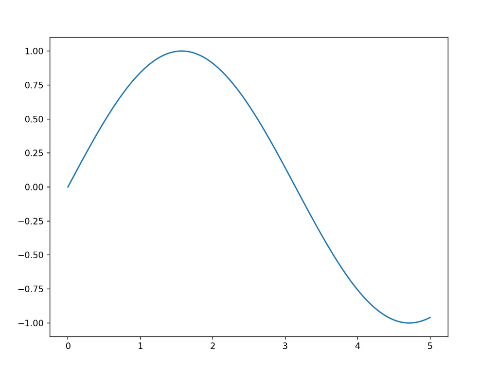

## Example of plot components: explanation

- **Figure**: `fig = plt.figure(figsize=(8, 6))` creates a Figure object.
- **Axes**: `ax = fig.add_axes([0.1, 0.1, 0.8, 0.8])` adds an Axes object to the Figure.
- **Axis**: The Axes object contains XAxis and YAxis objects (collectively referred to as Axis), which manage the data limits and the ticks.
- **Artist**: Everything drawn on the figure considered Artists. They are the visual elements that comprise the figure.

## Question

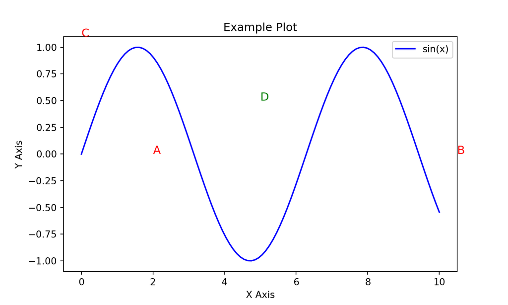

## Options

1. A: Axis, B: Artist, C: Axes, D: Figure
2. A: Artist, B: Axis, C: Artist, D: Artist
3. A: Axes, B: Figure, C: Axis, D: Artist
4. A: Figure, B: Axes, C: Axis, D: Artist

## Answer

**Solution**

**Correct Answer: 2**